# Classification Method Comparison Report

Tristan Sones-Dykes

02/10/23

## Summary

In this document, I compare some classification methods for SRP vs non SRP proteins using TM and SP region lengths and maximum hydropathy levels. This is through some clustering/unsupervised learning methods.

I also look at the accuracy of Phobius’ classification of protein regions into TM and SP regions for direct SRP targeting.

The common methodology is going to be: Plot the data, fit a model, plot the predictions, calculate the error.

## Unsupervised Learning

### Gaussian Mixture Model

#### 1D Gaussian Mixture Model

Initially, I used a mixture model on the length * max_height of the TM and SP regions, like in the original paper. This is a 2D plot of the data, with the mixture model fit to it; one for the Kyte-Doolittle and Rose scales.

```
## number of iterations= 149
```

```
## number of iterations= 14
```

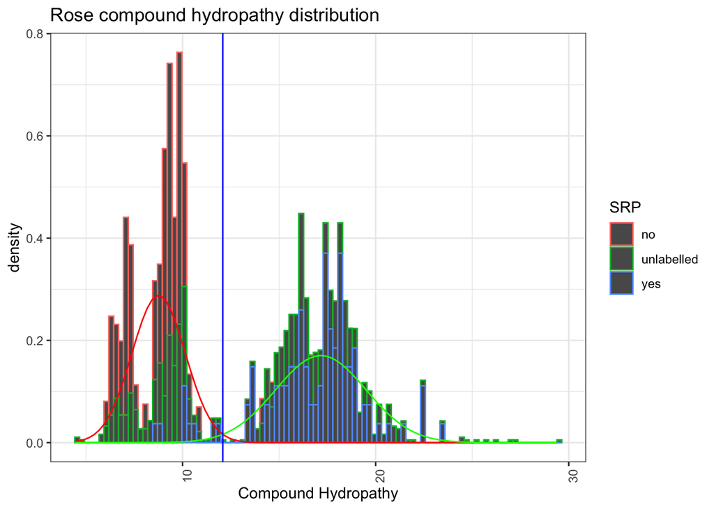

```
## $y
## [1] "Density"
##
## attr(,"class")
## [1] "labels"
```

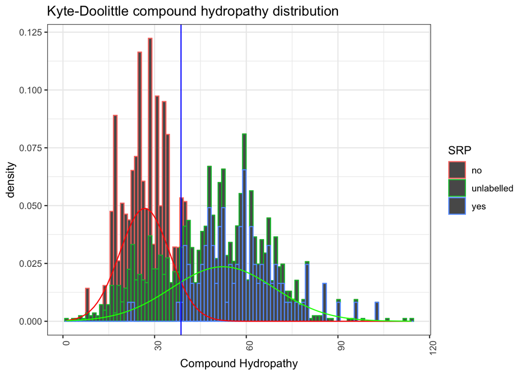

```
## $y
## [1] "Density"
##
## attr(,"class")
## [1] "labels"
```

It looks like the Rose scale has split the populations better then Kyte-Doolittle scale. Let’s compare the empirical errors of the two scales.

```
## [1] "Rose error: 0.0582"
```

```
## [1] "KD error: 0.037"
```

```
## [1] "Rose false positive: 0.0244 Rose false negative: 0.0841"
```

```
## [1] "KD false positive: 0.0366 KD false negative: 0.0374"
```

Rose has more negatives and less false positives, but overall very similar error. Let’s scatter the scales in 2D and see if we can see any patterns.

#### 2D Gaussian Mixture Model

[figure not shown]

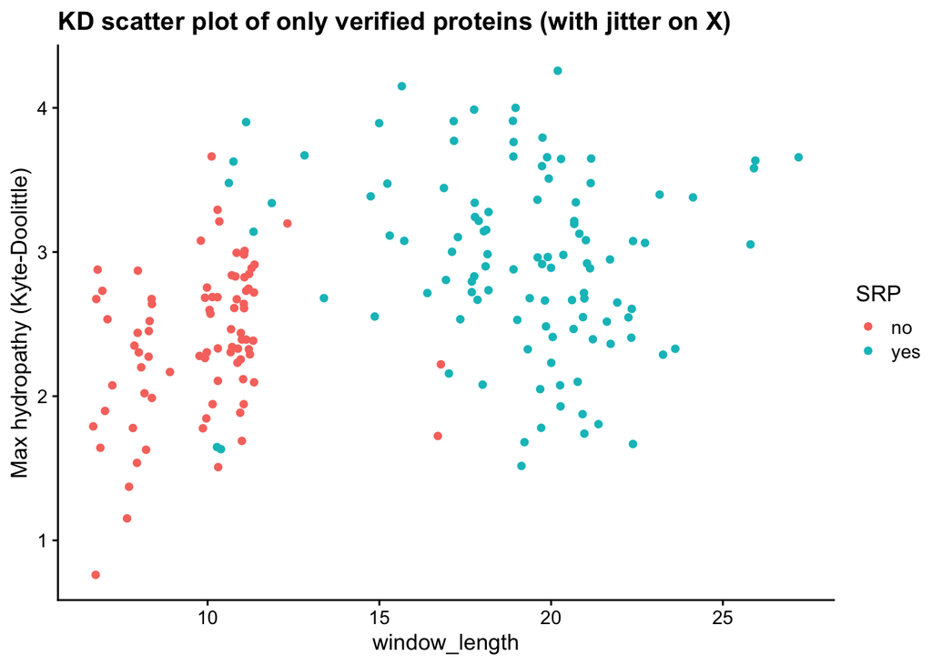

In the 2D scatter plots, we can see that there are two clear clusters of SRP and non-SRP proteins for both scales. This seems to primarily come from the window length, as is shown in the histogram.

Lets fit a 2D mixture model to the data and calculate errors.

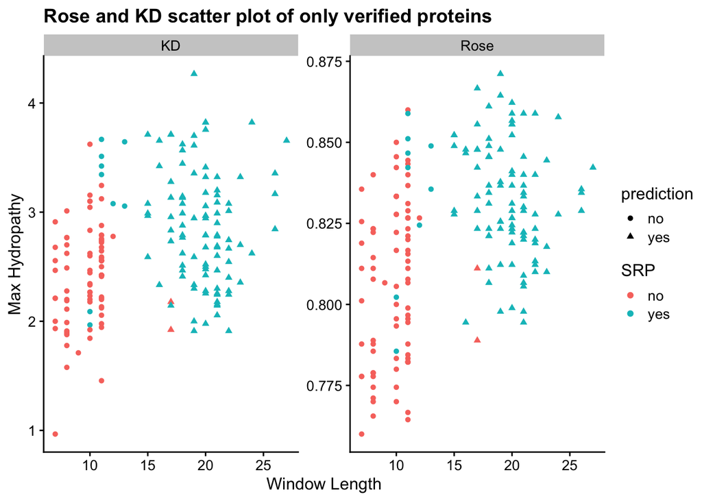

```
## [1] "Rose error: 0.0582"
```

```
## [1] "KD error: 0.0582"
```

```
## [1] "Rose false positive: 0.0244 Rose false negative: 0.0841"
```

```
## [1] "KD false positive: 0.0244 KD false negative: 0.0841"
```

#### Accuracy of only window length

Because the window length is not dependent on the scale, there is only one model.

```
## number of iterations= 15
```

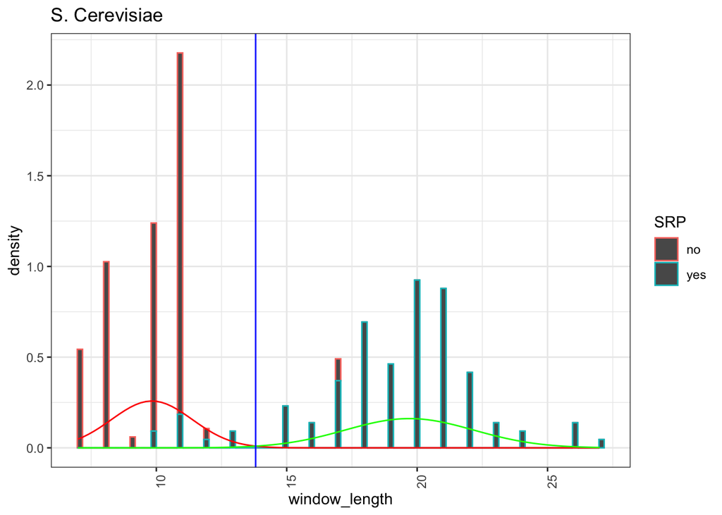

```
## [1] "window error: 0.0582"
```

```
## [1] "window false positive: 0.0244 window false negative: 0.0841"
```

This accuracy is the same as the compound hydropathy and 2D models for Rose.

### K-means

I’ll only do K-means on Rose as both scales seem to cluster the data identically

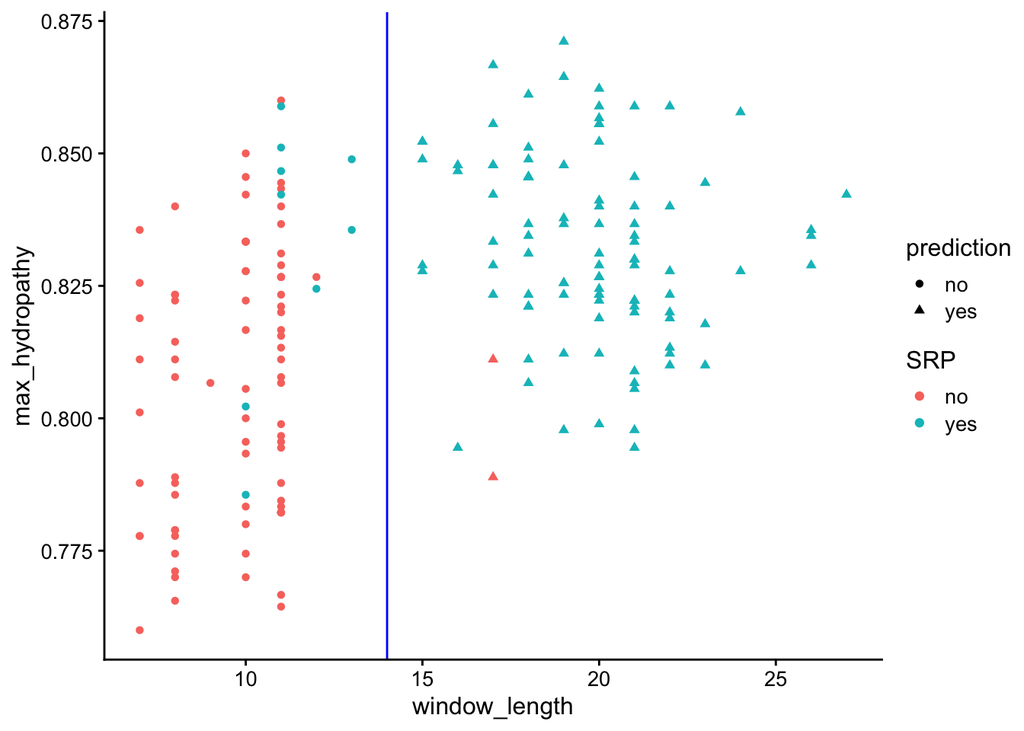

```
## [1] "kmeans error: 0.0582"
```

```
## [1] "kmeans false positive: 0.0244 kmeans false negative: 0.0841"
```

This shows that the K-means model is just as accurate as the GMM models, so there is no normal distribution assumption needed.

### Unsupervised Summary

Here is a table of the unsupervised models and their performances:

[output not shown]

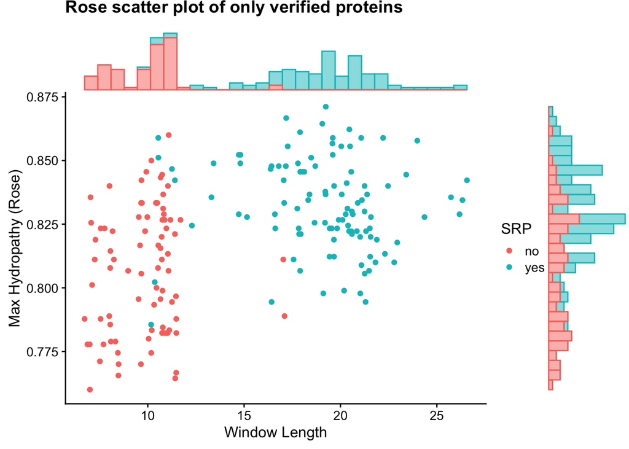

## Phobius classification

Phobius classifies proteins into TM and SP regions, and then labels different parts of the protein with regions depending on the classification. It looks like the TM and SP regions have a clear split in the hydropathy scores, so I’ll use this to classify the proteins.

[figure not shown]

It looks like the TM and SP regions have a clear split in the hydropathy scores, so I’ll use this to classify the proteins.

[figure not shown]

```
## [1] "phobius error: 0.0688"
```

```
## [1] "phobius false positive: 0.0244 phobius false negative: 0.1028"
```

So the Phobius Error is 0.01 higher than the unclassified window length model, all of this is caused by a higher number of false negatives.

## Conclusion

The “most accurate” model is the mixed Kyte-Doolittle model; however, the difference is very small and the GMM is far more mixed so would not hold it’s accuracy in a simulation study, and seems prevelant to outliers/overfitting.

The simplest model is just the phobius classification, it’s error is just above the window length model, primarily caused by a higher number of false negatives.

The window length model is a combination of simple and accurate.

[output not shown]